**Full name: Mai Xuan Bach**

**Student ID: 11200489**

# Modern Portfolio Theory (MPT)

Modern Portfolio Theory, or also known as **mean-variance analysis is a mathematical process which allows the user to maximize returns for a given risk level.**

It was formulated by H. Markowitz and while it is not the only optimization technique known, it is the most widely used.

MPT assumes that all investors are risk-averse, i.e, if there is a choice between low risk and high risk portfolios with the same returns, an investor will choose one with the low risk.

So, what is the MPT all about?

**MPT encourages diversification of assets. It says that a high variance asset A if combined with diverse assets B and C, where A, B and C have little to no correlation, can give us a portfolio with low variance on returns.**

This is the crux of the Modern Portfolio Theory.

# Understanding Efficient Frontier

The efficient frontier is the **set of optimal portfolios that offer the highest expected return for a defined level of risk or the lowest risk for a given level of expected return**. Portfolios that lie below the efficient frontier are sub-optimal because they do not provide enough return for the level of risk. Portfolios that cluster to the right of the efficient frontier are sub-optimal because they have a higher level of risk for the defined rate of return.

**Efficient frontier is a graph with ‘returns’ on the Y-axis and ‘volatility’ on the X-axis.** It shows the set of optimal portfolios that offer the highest expected return for a given risk level or the lowest risk for a given level of expected return.

The source of definition is referenced from: https://www.investopedia.com/terms/e/efficientfrontier.asp

# Basic concepts in portfolio optimization

## Import libraries

```python
!pip install quandl
```

```python
import pandas as pd
import numpy as np
import matplotlib.pyplot as plt
import seaborn as sns
import quandl
import scipy.optimize as sco
from datetime import datetime

plt.style.use('fivethirtyeight')
np.random.seed(777)

%matplotlib inline
%config InlineBackend.figure_format = 'retina'
```

## Read dataset

```python
test = pd.read_excel("/content/portfolio_stock_prices.xlsx", index_col= 0)
test
```

| time | vcb | ctg | bid | vnm | hpg | mwg | msn | vhc | fpt |
| --- | --- | --- | --- | --- | --- | --- | --- | --- | --- |
| 20210104 | 76.6450 | 26.8478 | 38.1861 | 99.5315 | 23.5371 | 39.8188 | 72.7990 | 39.6855 | 41.8500 |
| 20210105 | 76.8772 | 26.7721 | 37.9091 | 101.8257 | 23.5650 | 40.2480 | 73.1266 | 39.6382 | 43.5880 |
| 20210106 | 81.2901 | 28.6250 | 38.6213 | 100.9067 | 23.8154 | 40.0499 | 72.3077 | 38.8350 | 43.3794 |
| 20210107 | 82.8385 | 29.3813 | 38.7005 | 101.4581 | 23.8154 | 39.8848 | 75.3376 | 39.3075 | 43.4489 |
| 20210108 | 81.1353 | 29.2679 | 38.3839 | 102.9285 | 23.7875 | 40.2150 | 76.2384 | 39.4965 | 44.0051 |
| ... | ... | ... | ... | ... | ... | ... | ... | ... | ... |
| 20221226 | 78.9000 | 26.0500 | 38.8000 | 76.0000 | 17.1000 | 42.6000 | 91.5000 | 66.9000 | 76.4000 |
| 20221227 | 79.1000 | 26.6000 | 40.0000 | 76.6000 | 18.2500 | 43.8000 | 91.6000 | 69.0000 | 76.5000 |
| 20221228 | 80.0000 | 27.1500 | 41.9000 | 77.0000 | 18.2000 | 43.0000 | 93.0000 | 69.8000 | 76.7000 |
| 20221229 | 80.7000 | 27.0000 | 40.0000 | 77.0000 | 18.0000 | 42.9000 | 94.0000 | 68.8000 | 76.2000 |
| 20221230 | 80.0000 | 27.2500 | 38.6000 | 76.1000 | 18.0000 | 42.9000 | 93.0000 | 69.8000 | 76.9000 |

499 rows × 9 columns

**The dataset is comprised of 9 stock price series from Vietnam Stock Market. Time ranges from 2021-01-04 to 2022-12-30 (2 years of trading).**

```python
test.shape
```

```
(499, 9)
```

**Dataframe has 499 rows, 9 columns, which are equivalent to 9 stock price series.**

```python
test.info()
```

```
<class 'pandas.core.frame.DataFrame'>
Int64Index: 499 entries, 20210104 to 20221230
Data columns (total 9 columns):
 #   Column  Non-Null Count  Dtype
---  ------  --------------  -----
 0   vcb     499 non-null    float64
 1   ctg     499 non-null    float64
 2   bid     499 non-null    float64
 3   vnm     499 non-null    float64
 4   hpg     499 non-null    float64
 5   mwg     499 non-null    float64
 6   msn     499 non-null    float64
 7   vhc     499 non-null    float64
 8   fpt     499 non-null    float64
dtypes: float64(9)
memory usage: 39.0 KB
```

## Calculate log of percentage change

The reason for this is that **log of the returns is time additive.**

For example: If p1 = 100, p2 = 110 and p3 = 120, where p1 is price of stock in time 1

Then:

log(r12) = ln(p2/p1) = ln(110/100) = 9.53%,

log(r23) = ln(120/110) = 8.7% and

log(r13) = log(r12) + log(r23) = 9.53 + 8.7 = 18.23%, which is same as ln(120/100).

This means a log change of +0.1 today and then -0.1 tomorrow will give you the same value of stock as yesterday. This is not true if you simply compute percentage change.

It is common practice in portfolio optimization to take log of returns for calculations of covariance and correlation.

**Let take an example of VCB (Vietcombank)**

```python
# Log of percentage change
vcb = test['vcb'].pct_change().apply(lambda x: np.log(1+x))
vcb.head()
```

```
time
20210104         NaN
20210105    0.003025
20210106    0.055815
20210107    0.018869
20210108   -0.020775
Name: vcb, dtype: float64
```

## Variance

The variance in prices of stocks are an important indicator of how volatile this investment will be (how returns can fluctuate).

```python
# variance of VCB
var_vcb = vcb.var()
var_vcb
```

```
0.00034038298505623344
```

Similarly, we can compute variance of log percentage change of **vhc stock price (Vinh Hoan company)**

```python
vhc = test['vhc'].pct_change().apply(lambda x: np.log(1+x))
var_vhc = vhc.var()
var_vhc
```

```
0.000911978698382087
```

## Volatility

Volatility is measured as the standard deviation of a company’s stock. But volatility for the annual standard deviation. What we get from square root of variance is the daily standard deviation. To convert it to annual standard deviation we multiply the variance by *t*.

First, we have to see if how many trading days in a year (t)

```python
test.loc[20210104 : 20211231, :]
```

| time | vcb | ctg | bid | vnm | hpg | mwg | msn | vhc | fpt |
| --- | --- | --- | --- | --- | --- | --- | --- | --- | --- |
| 20210104 | 76.6450 | 26.8478 | 38.1861 | 99.5315 | 23.5371 | 39.8188 | 72.7990 | 39.6855 | 41.8500 |
| 20210105 | 76.8772 | 26.7721 | 37.9091 | 101.8257 | 23.5650 | 40.2480 | 73.1266 | 39.6382 | 43.5880 |
| 20210106 | 81.2901 | 28.6250 | 38.6213 | 100.9067 | 23.8154 | 40.0499 | 72.3077 | 38.8350 | 43.3794 |
| 20210107 | 82.8385 | 29.3813 | 38.7005 | 101.4581 | 23.8154 | 39.8848 | 75.3376 | 39.3075 | 43.4489 |
| 20210108 | 81.1353 | 29.2679 | 38.3839 | 102.9285 | 23.7875 | 40.2150 | 76.2384 | 39.4965 | 44.0051 |
| ... | ... | ... | ... | ... | ... | ... | ... | ... | ... |
| 20211227 | 79.8000 | 33.4000 | 35.3000 | 81.4933 | 34.7383 | 67.0141 | 139.8046 | 61.5564 | 77.1399 |
| 20211228 | 80.0000 | 33.9000 | 35.2000 | 80.9254 | 34.6626 | 67.4612 | 141.8727 | 62.8226 | 77.1399 |
| 20211229 | 79.5000 | 34.1500 | 35.2000 | 80.6415 | 34.6626 | 66.7657 | 142.2863 | 61.8486 | 76.4052 |
| 20211230 | 78.4000 | 33.8000 | 35.4000 | 80.7361 | 34.5869 | 66.7160 | 141.8727 | 61.5564 | 76.4052 |
| 20211231 | 78.8000 | 33.9000 | 37.1000 | 81.7773 | 35.1167 | 67.5108 | 141.4591 | 61.1668 | 75.9154 |

250 rows × 9 columns

```python
test.loc[20220104 : 20221230, :]
```

| time | vcb | ctg | bid | vnm | hpg | mwg | msn | vhc | fpt |
| --- | --- | --- | --- | --- | --- | --- | --- | --- | --- |
| 20220104 | 79.0 | 34.75 | 37.40 | 82.0612 | 35.3816 | 68.4547 | 140.6319 | 61.2642 | 76.3236 |
| 20220105 | 78.0 | 34.75 | 37.05 | 81.5880 | 35.4194 | 68.1070 | 133.1866 | 65.5498 | 76.4052 |
| 20220106 | 79.1 | 34.00 | 38.00 | 80.8308 | 34.8896 | 68.3057 | 127.2305 | 65.2576 | 76.3236 |
| 20220107 | 79.8 | 33.20 | 39.20 | 80.6415 | 34.6626 | 67.3121 | 127.3959 | 65.3550 | 76.2419 |
| 20220110 | 79.5 | 33.30 | 38.85 | 80.5447 | 34.5490 | 66.0702 | 126.5687 | 61.8486 | 75.0991 |
| ... | ... | ... | ... | ... | ... | ... | ... | ... | ... |
| 20221226 | 78.9 | 26.05 | 38.80 | 76.0000 | 17.1000 | 42.6000 | 91.5000 | 66.9000 | 76.4000 |
| 20221227 | 79.1 | 26.60 | 40.00 | 76.6000 | 18.2500 | 43.8000 | 91.6000 | 69.0000 | 76.5000 |
| 20221228 | 80.0 | 27.15 | 41.90 | 77.0000 | 18.2000 | 43.0000 | 93.0000 | 69.8000 | 76.7000 |
| 20221229 | 80.7 | 27.00 | 40.00 | 77.0000 | 18.0000 | 42.9000 | 94.0000 | 68.8000 | 76.2000 |
| 20221230 | 80.0 | 27.25 | 38.60 | 76.1000 | 18.0000 | 42.9000 | 93.0000 | 69.8000 | 76.9000 |

249 rows × 9 columns

**We can see that, in 2021, there is 250 trading days. That of 2022 is 249. Then, we can choose t = 250 or t = 249.**

```python
# Volatility
vcb_vol = np.sqrt(var_vcb * 250)
vhc_vol = np.sqrt(var_vhc * 250)
vcb_vol, vhc_vol
```

```
(0.29171175201568134, 0.477487879003773)
```

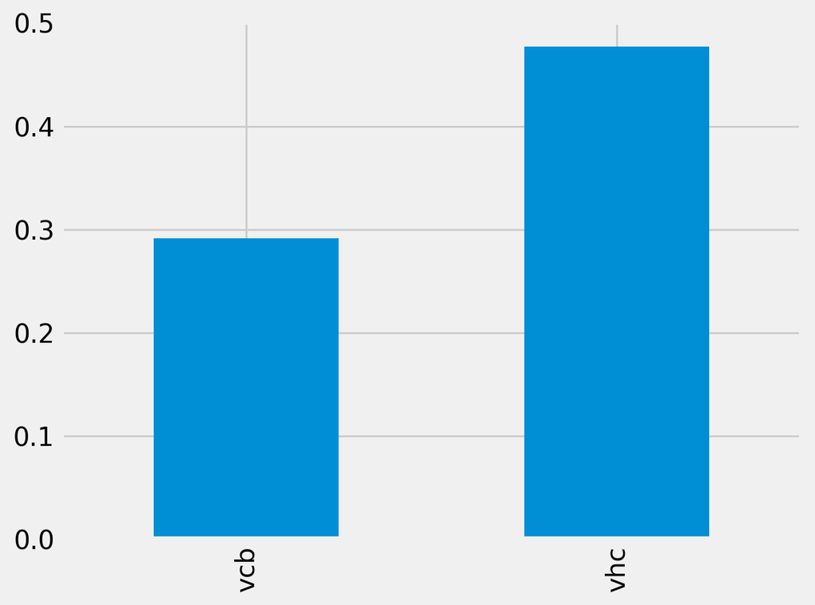

```python
# Volatility of both stocks
test[["vcb", "vhc"]].pct_change().apply(lambda x: np.log(1+x)).std().apply(lambda x: x*np.sqrt(250)).plot(kind='bar')
```

## Covariance

**Covariance measures the directional relationship between the returns on two assets.**

A positive covariance means that returns of the two assets move together while a negative covariance means they move inversely. Risk and volatility can be reduced in a portfolio by pairing assets that have a negative covariance.

```python
# Log of Percentage change
test1 = test.pct_change().apply(lambda x: np.log(1+x))
test1.head()
```

| time | vcb | ctg | bid | vnm | hpg | mwg | msn | vhc | fpt |
| --- | --- | --- | --- | --- | --- | --- | --- | --- | --- |
| 20210104 | NaN | NaN | NaN | NaN | NaN | NaN | NaN | NaN | NaN |
| 20210105 | 0.003025 | -0.002824 | -0.007280 | 0.022788 | 0.001185 | 0.010721 | 0.004490 | -0.001193 | 0.040690 |
| 20210106 | 0.055815 | 0.066920 | 0.018613 | -0.009066 | 0.010570 | -0.004934 | -0.011262 | -0.020471 | -0.004797 |
| 20210107 | 0.018869 | 0.026078 | 0.002049 | 0.005450 | 0.000000 | -0.004131 | 0.041049 | 0.012093 | 0.001601 |
| 20210108 | -0.020775 | -0.003867 | -0.008214 | 0.014389 | -0.001172 | 0.008245 | 0.011886 | 0.004797 | 0.012720 |

```python
test1.cov()
```

|  | vcb | ctg | bid | vnm | hpg | mwg | msn | vhc | fpt |
| --- | --- | --- | --- | --- | --- | --- | --- | --- | --- |
| vcb | 0.000340 | 0.000264 | 0.000236 | 0.000118 | 0.000195 | 0.000188 | 0.000184 | 0.000128 | 0.000145 |
| ctg | 0.000264 | 0.000667 | 0.000465 | 0.000147 | -0.000200 | 0.000296 | 0.000260 | 0.000230 | 0.000275 |
| bid | 0.000236 | 0.000465 | 0.000597 | 0.000167 | 0.000272 | 0.000281 | 0.000229 | 0.000226 | 0.000242 |
| vnm | 0.000118 | 0.000147 | 0.000167 | 0.000257 | 0.000190 | 0.000131 | 0.000146 | 0.000122 | 0.000141 |
| hpg | 0.000195 | -0.000200 | 0.000272 | 0.000190 | 0.088862 | -0.000228 | -0.000131 | -0.000062 | -0.000036 |
| mwg | 0.000188 | 0.000296 | 0.000281 | 0.000131 | -0.000228 | 0.000614 | 0.000314 | 0.000302 | 0.000302 |
| msn | 0.000184 | 0.000260 | 0.000229 | 0.000146 | -0.000131 | 0.000314 | 0.000679 | 0.000260 | 0.000221 |
| vhc | 0.000128 | 0.000230 | 0.000226 | 0.000122 | -0.000062 | 0.000302 | 0.000260 | 0.000912 | 0.000233 |
| fpt | 0.000145 | 0.000275 | 0.000242 | 0.000141 | -0.000036 | 0.000302 | 0.000221 | 0.000233 | 0.000397 |

```python
test1["vcb"].cov(test1["vhc"])
```

```
0.00012836463305715775
```

**We can notice that there is small positive covariance between Vinh Hoan and Vietcombank.**

## Correlation

Correlation, in the finance and investment industries, is a statistic that measures the degree to which two securities move in relation to each other. Correlations are used in advanced portfolio management, computed as the correlation coefficient, which has a value that must fall between -1.0 and +1.0.

```python
test1.corr()
```

|  | vcb | ctg | bid | vnm | hpg | mwg | msn | vhc | fpt |
| --- | --- | --- | --- | --- | --- | --- | --- | --- | --- |
| vcb | 1.000000 | 0.554975 | 0.523914 | 0.398725 | 0.035544 | 0.410931 | 0.381852 | 0.230393 | 0.395745 |
| ctg | 0.554975 | 1.000000 | 0.737225 | 0.355491 | -0.025915 | 0.463195 | 0.386272 | 0.294455 | 0.535067 |
| bid | 0.523914 | 0.737225 | 1.000000 | 0.426864 | 0.037404 | 0.465117 | 0.359642 | 0.306940 | 0.497256 |
| vnm | 0.398725 | 0.355491 | 0.426864 | 1.000000 | 0.039686 | 0.329687 | 0.348617 | 0.252168 | 0.440717 |
| hpg | 0.035544 | -0.025915 | 0.037404 | 0.039686 | 1.000000 | -0.030938 | -0.016893 | -0.006843 | -0.006088 |
| mwg | 0.410931 | 0.463195 | 0.465117 | 0.329687 | -0.030938 | 1.000000 | 0.486969 | 0.403587 | 0.612659 |
| msn | 0.381852 | 0.386272 | 0.359642 | 0.348617 | -0.016893 | 0.486969 | 1.000000 | 0.329901 | 0.426472 |
| vhc | 0.230393 | 0.294455 | 0.306940 | 0.252168 | -0.006843 | 0.403587 | 0.329901 | 1.000000 | 0.387418 |
| fpt | 0.395745 | 0.535067 | 0.497256 | 0.440717 | -0.006088 | 0.612659 | 0.426472 | 0.387418 | 1.000000 |

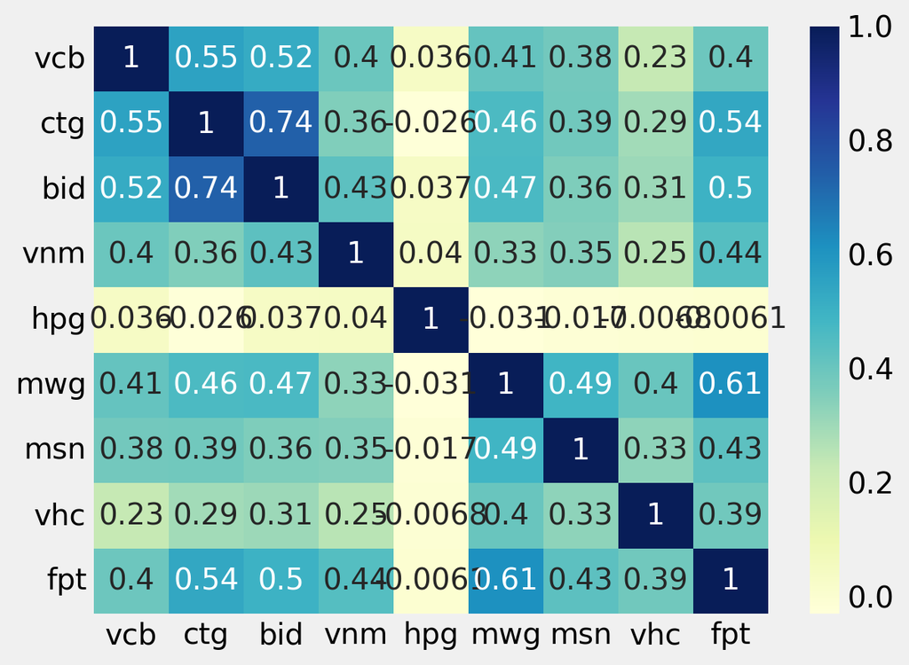

```python
dataplot = sns.heatmap(test1.corr(), cmap="YlGnBu", annot=True)
```

From the correlation matrix, note that:

**- BID (BIDV) and CTG (Vietinbank) are highly positvely correlated at 0.74**

**- FPT (FPT) and MWG (TheGioiDiDong) are relatively highly positively correlated (0.61)**

**- HPG (Hoa Phat) is nearly negatively correlated with other stocks**

## Expected Returns

Expected returns of an asset are simply the mean of percentage change in its stock prices. So, the value of expected return we obtain here are daily expected returns.

For expected returns, you need to define weights for the assets choosen.

In simpler terms, this means you need to decide what percentage of your total money to you want to hold in each company’s stock.

Usually this decision is done by using the optimization techniques we will discuss later but for now we will consider random weights for VHC and VCB.

First, let’s compute the log of percentage change.

```python
test2 = test.pct_change().apply(lambda x: np.log(1+x))
test2.head()
```

| time | vcb | ctg | bid | vnm | hpg | mwg | msn | vhc | fpt |
| --- | --- | --- | --- | --- | --- | --- | --- | --- | --- |
| 20210104 | NaN | NaN | NaN | NaN | NaN | NaN | NaN | NaN | NaN |
| 20210105 | 0.003025 | -0.002824 | -0.007280 | 0.022788 | 0.001185 | 0.010721 | 0.004490 | -0.001193 | 0.040690 |
| 20210106 | 0.055815 | 0.066920 | 0.018613 | -0.009066 | 0.010570 | -0.004934 | -0.011262 | -0.020471 | -0.004797 |
| 20210107 | 0.018869 | 0.026078 | 0.002049 | 0.005450 | 0.000000 | -0.004131 | 0.041049 | 0.012093 | 0.001601 |
| 20210108 | -0.020775 | -0.003867 | -0.008214 | 0.014389 | -0.001172 | 0.008245 | 0.011886 | 0.004797 | 0.012720 |

### Weights

Let’s define an array of random weights for the purpose of calculation. These weights will represent the percentage allocation of investments between these two stocks. They must add up to 1.

So, the problem of portfolio optimization is nothing but to find the optimal values of weights that maximizes expected returns while minimizing the risk (standard deviation).

```python
# Define weights for allocation
w = [0.2, 0.8]
e_r_ind = test2[["vcb", "vhc"]].mean()
e_r_ind
```

```
vcb    0.000086
vhc    0.001134
dtype: float64
```

```python
# Total expected return
e_r = (e_r_ind*w).sum()
e_r
```

```
0.000924270994136485
```

# Building an optimal risky portfolio

**We will be using stocks from 4 banks, namely, MB Bank, VIB, Viettinbank and BIDV for a period of 2 years (2021 - 2022).**

I will calculate the weights of assets for each one. Then, I will calculate the expected returns, minimum variance portfolio, optimal risky portfolio and efficient frontier. I will also mention a term called Sharpe Ratio.

```python
df= pd.read_excel("/content/stock_price_180423.xlsx", index_col= 0)
df.index = pd.to_datetime(df.reset_index()["Time"].astype("str"))
df = df[[x.upper() for x in ['mbb', 'vib', 'ctg', "bid"]]]
df
```

| Time | MBB | VIB | CTG | BID |
| --- | --- | --- | --- | --- |
| 2021-01-04 | 17.5784 | 16.7084 | 26.8478 | 38.1861 |
| 2021-01-05 | 18.4591 | 17.8730 | 26.7721 | 37.9091 |
| 2021-01-06 | 18.7407 | 17.8983 | 28.6250 | 38.6213 |
| 2021-01-07 | 19.1852 | 17.7211 | 29.3813 | 38.7005 |
| 2021-01-08 | 19.7037 | 17.5945 | 29.2679 | 38.3839 |
| ... | ... | ... | ... | ... |
| 2022-12-26 | 16.8000 | 17.5598 | 26.0500 | 38.8000 |
| 2022-12-27 | 17.2500 | 18.1818 | 26.6000 | 40.0000 |
| 2022-12-28 | 17.4500 | 18.1818 | 27.1500 | 41.9000 |
| 2022-12-29 | 17.4000 | 18.0861 | 27.0000 | 40.0000 |
| 2022-12-30 | 17.1000 | 18.1818 | 27.2500 | 38.6000 |

499 rows × 4 columns

```python
df.columns
```

```
Index(['MBB', 'VIB', 'CTG', 'BID'], dtype='object')
```

```python
table = df.copy()
```

## Visualize the price series in 2 years range

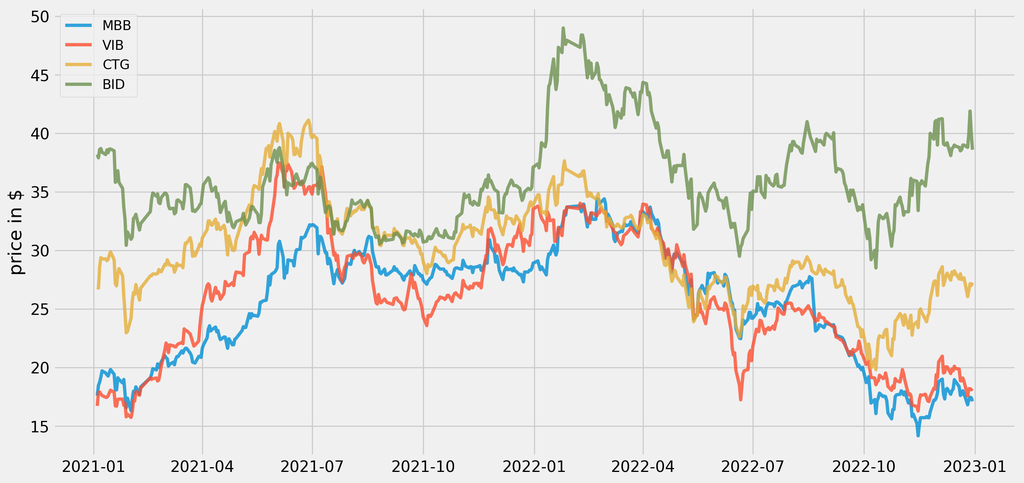

```python
plt.figure(figsize=(14, 7))
for c in table.columns.values:
    plt.plot(table.index, table[c], lw=3, alpha=0.8,label=c)
plt.legend(loc='upper left', fontsize=12)
plt.ylabel('price in $')
```

It is a bit hard to track the movement of these series. Then we can plot daily returns (percent change compared to the day before). By plotting daily returns instead of actual prices, we can see the stocks' volatility.

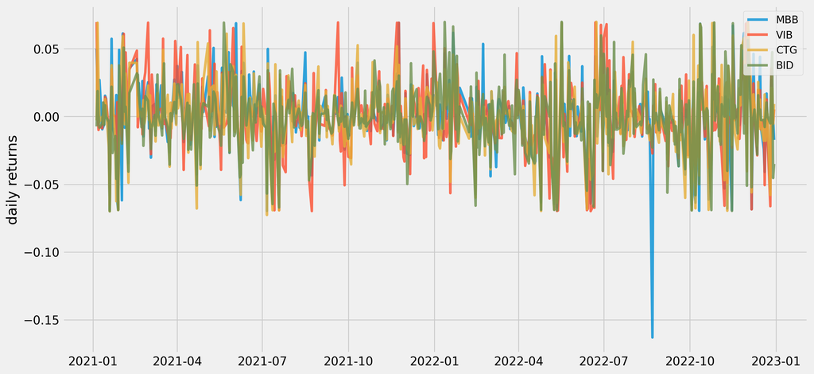

```python
returns = table.pct_change()

plt.figure(figsize=(14, 7))
for c in returns.columns.values:
    plt.plot(returns.index, returns[c], lw=3, alpha=0.8,label=c)
plt.legend(loc='upper right', fontsize=12)
plt.ylabel('daily returns')
```

## Random Portfolios Generation

We have 4 stocks in our portfolio. One decision we have to make is how we should allocate our budget to each of stock in our portfolio. If our total budget is 1, then we can decide the weights for each stock, so that the sum of weights will be 1. And the value for weights will be the portion of budget we allocate to a specific stock. For example, if weight is 0.5 for BID, it means that we allocate 50% of our budget to BID.

Let's define some functions to simulate random weights to each stock in the portfolio, then calculate the portfolio's overall annualised returns and annualised volatility.

"portfolio_annual_performance" function will calculate the returns and volatility, and to make it as an annualised calculation I take into account 250 as the number of trading days in one year. "random_portfolios" function will generate portfolios with random weights assigned to each stock, and by passing num_portfolios argument, you can decide how many random portfolios you want to generate.

```python
trading_days_per_year = 250
n_stocks = 4
```

```python
def portfolio_annualised_performance(weights, mean_returns, cov_matrix):
    returns = np.sum(mean_returns*weights ) *trading_days_per_year
    std = np.sqrt(np.dot(weights.T, np.dot(cov_matrix, weights))) * np.sqrt(trading_days_per_year)
    return std, returns
```

```python
def random_portfolios(num_portfolios, mean_returns, cov_matrix, risk_free_rate):
    results = np.zeros((3,num_portfolios))
    weights_record = []
    for i in range(num_portfolios):
        weights = np.random.random(n_stocks)
        weights /= np.sum(weights)
        weights_record.append(weights)
        portfolio_std_dev, portfolio_return = portfolio_annualised_performance(weights, mean_returns, cov_matrix)
        results[0,i] = portfolio_std_dev
        results[1,i] = portfolio_return
        results[2,i] = (portfolio_return - risk_free_rate) / portfolio_std_dev
    return results, weights_record
```

You can easily get daily returns by calling pct_change on the data frame with the price data. And the mean daily returns, the covariance matrix of returns are needed to calculate portfolio returns and volatility. Finally, let's generate 50,000 portfolios with random weights assigned to each stock.

```python
returns = table.pct_change()
mean_returns = returns.mean()
cov_matrix = returns.cov()
num_portfolios = 50000
risk_free_rate = 0.0178
```

Let me briefly explain what below function is doing. First, it generates random portfolio and gets the results (portfolio returns, portfolio volatility, portfolio Sharpe ratio) and weights for the corresponding result. Then by locating the one with the highest Sharpe ratio portfolio, it displays maximum Sharpe ratio portfolio as red star sign. And does similar steps for minimum volatility portfolio, and displays it as the green star on the plot. All the randomly generated portfolios will be also plotted with colour map applied to them based on the Sharpe ratio. The bluer, the higher Sharpe ratio.

And for these two optimal portfolios, it will also show how it allocates the budget within the portfolio.

```python
def display_simulated_ef_with_random(mean_returns, cov_matrix, num_portfolios, risk_free_rate):
    results, weights = random_portfolios(num_portfolios,mean_returns, cov_matrix, risk_free_rate)

    max_sharpe_idx = np.argmax(results[2])
    sdp, rp = results[0,max_sharpe_idx], results[1,max_sharpe_idx]
    max_sharpe_allocation = pd.DataFrame(weights[max_sharpe_idx],index=table.columns,columns=['allocation'])
    max_sharpe_allocation.allocation = [round(i*100,2)for i in max_sharpe_allocation.allocation]
    max_sharpe_allocation = max_sharpe_allocation.T

    min_vol_idx = np.argmin(results[0])
    sdp_min, rp_min = results[0,min_vol_idx], results[1,min_vol_idx]
    min_vol_allocation = pd.DataFrame(weights[min_vol_idx],index=table.columns,columns=['allocation'])
    min_vol_allocation.allocation = [round(i*100,2)for i in min_vol_allocation.allocation]
    min_vol_allocation = min_vol_allocation.T

    print ("-"*80)
    print ("Maximum Sharpe Ratio Portfolio Allocation\n")
    print ("Annualised Return:", round(rp,2))
    print ("Annualised Volatility:", round(sdp,2))
    print ("\n")
    print (max_sharpe_allocation)
    print ("-"*80)
    print ("Minimum Volatility Portfolio Allocation\n")
    print ("Annualised Return:", round(rp_min,2))
    print ("Annualised Volatility:", round(sdp_min,2))
    print ("\n")
    print (min_vol_allocation)

    plt.figure(figsize=(10, 7))
    plt.scatter(results[0,:],results[1,:],c=results[2,:],cmap='YlGnBu', marker='o', s=10, alpha=0.3)
    plt.colorbar()
    plt.scatter(sdp,rp,marker='*',color='r',s=500, label='Maximum Sharpe ratio')
    plt.scatter(sdp_min,rp_min,marker='*',color='g',s=500, label='Minimum volatility')
    plt.title('Simulated Portfolio Optimization based on Efficient Frontier')
    plt.xlabel('annualised volatility')
    plt.ylabel('annualised returns')
    plt.legend(labelspacing=0.8)
```

```
--------------------------------------------------------------------------------
Maximum Sharpe Ratio Portfolio Allocation

Annualised Return: 0.12
Annualised Volatility: 0.38


             MBB    VIB    CTG   BID
allocation  0.62  81.69  16.14  1.56
--------------------------------------------------------------------------------
Minimum Volatility Portfolio Allocation

Annualised Return: 0.1
Annualised Volatility: 0.34


              MBB    VIB    CTG   BID
allocation  11.88  33.98  15.03  39.1
```

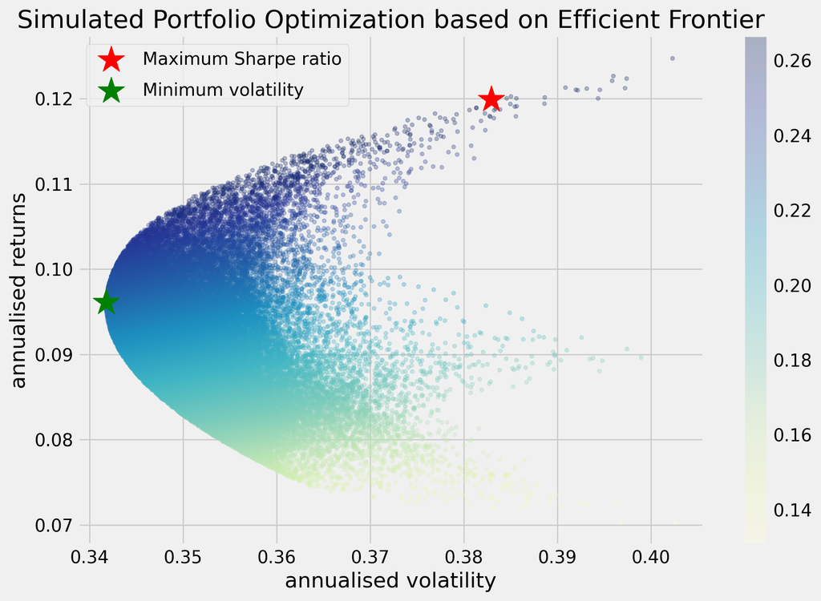

```python
display_simulated_ef_with_random(mean_returns, cov_matrix, num_portfolios, risk_free_rate)
```

For minimum risk portfolio, we can see that about 40% of our budget is allocated in BID.

If we are willing to take higher risk for higher return, one that gives us the best risk-adjusted return is the one with maximum Sharpe ratio. In this scenario, we are allocating a significant portion to VIB, which is quite volatile stocks from the previous plot of daily returns. And BID which had nearly 40% allocation in the minimum risk portfolio, has less than 2% budget allocated to it.

## Efficient Frontier

From the plot of the randomly simulated portfolio, we can see it forms a shape of an arch line on the top of clustered blue dots. This line is called efficient frontier. Why is it efficient? Because points along the line will give you the lowest risk for a given target return. All the other dots right to the line will give you higher risk with same returns. If the expected returns are the same, why would you take an extra risk when there's an option with lower risk?

The way we found the two kinds of optimal portfolio above was by simulating many possible random choices and pick the best ones (either minimum risk or maximum risk-adjusted return). We can also implement this by using Scipy's optimize function.

If you are an advanced Excel user, you might be familiar with 'solver' function in excel. Scipy's optimize function is doing the similar task when given what to optimize, and what are constraints and bounds.

Below functions are to get the maximum Sharpe ratio portfolio. In Scipy's optimize function, there's no 'maximize', so as an objective function you need to pass something that should be minimized. That is why the first "neg_sharpe_ratio" is computing the negative Sharpe ratio. Now we can use this as our objective function to minimize. In "max_sharpe_ratio" function, you first define arguments (this should not include the variables you would like to change for optimisation, in this case, "weights").

constraints = ({'type': 'eq', 'fun': lambda x: np.sum(x) - 1})

The above constraint is saying that sum of x should be equal to 1. You can think of the 'fun' part construction as '1' on the right side of equal sign has been moved to the left side of the equal sign.

'np.sum(x) == 1' has become 'np.sum(x)-1'

And what does this mean? It simply means that the sum of all the weights should be equal to 1. You cannot allocate more than 100% of your budget in total.

"bounds" is giving another limit to assign random weights, by saying any weight should be inclusively between 0 and 1. You cannot give minus budget allocation to a stock or more than 100% allocation to a stock.

```python
def neg_sharpe_ratio(weights, mean_returns, cov_matrix, risk_free_rate):
    p_var, p_ret = portfolio_annualised_performance(weights, mean_returns, cov_matrix)
    return -(p_ret - risk_free_rate) / p_var

def max_sharpe_ratio(mean_returns, cov_matrix, risk_free_rate):
    num_assets = len(mean_returns)
    args = (mean_returns, cov_matrix, risk_free_rate)
    constraints = ({'type': 'eq', 'fun': lambda x: np.sum(x) - 1})
    bound = (0.0,1.0)
    bounds = tuple(bound for asset in range(num_assets))
    result = sco.minimize(neg_sharpe_ratio, num_assets*[1./num_assets,], args=args,
                        method='SLSQP', bounds=bounds, constraints=constraints)
    return result
```

We can also define the optimizing function for calculating minimum volatility portfolio. This time we really do minimize the objective function. What do we want to minimize? We want to minimize volatility by trying different weights. "constraints" and "bounds" are same as the above.

```python
def portfolio_volatility(weights, mean_returns, cov_matrix):
    return portfolio_annualised_performance(weights, mean_returns, cov_matrix)[0]

def min_variance(mean_returns, cov_matrix):
    num_assets = len(mean_returns)
    args = (mean_returns, cov_matrix)
    constraints = ({'type': 'eq', 'fun': lambda x: np.sum(x) - 1})
    bound = (0.0,1.0)
    bounds = tuple(bound for asset in range(num_assets))

    result = sco.minimize(portfolio_volatility, num_assets*[1./num_assets,], args=args,
                        method='SLSQP', bounds=bounds, constraints=constraints)

    return result
```

As I already mentioned above we can also draw a line which depicts where the efficient portfolios for a given risk rate should be. This is called "efficient frontier". Below I define other functions to compute efficient frontier. The first function "efficient_return" is calculating the most efficient portfolio for a given target return, and the second function "efficient_frontier" will take a range of target returns and compute efficient portfolio for each return level.

```python
def efficient_return(mean_returns, cov_matrix, target):
    num_assets = len(mean_returns)
    args = (mean_returns, cov_matrix)

    def portfolio_return(weights):
        return portfolio_annualised_performance(weights, mean_returns, cov_matrix)[1]

    constraints = ({'type': 'eq', 'fun': lambda x: portfolio_return(x) - target},
                   {'type': 'eq', 'fun': lambda x: np.sum(x) - 1})
    bounds = tuple((0,1) for asset in range(num_assets))
    result = sco.minimize(portfolio_volatility, num_assets*[1./num_assets,], args=args, method='SLSQP', bounds=bounds, constraints=constraints)
    return result


def efficient_frontier(mean_returns, cov_matrix, returns_range):
    efficients = []
    for ret in returns_range:
        efficients.append(efficient_return(mean_returns, cov_matrix, ret))
    return efficients
```

Let's try to plot the portfolio choice with maximum Sharpe ratio and minimum volatility also with all the randomly generated portfolios. But this time we are not picking the optimal ones from the randomly generated portfolios, but we are actually calculating by using Scipy's 'minimize' function. And the below function will also plot the efficient frontier line.

```python
def display_calculated_ef_with_random(mean_returns, cov_matrix, num_portfolios, risk_free_rate):
    results, _ = random_portfolios(num_portfolios,mean_returns, cov_matrix, risk_free_rate)

    max_sharpe = max_sharpe_ratio(mean_returns, cov_matrix, risk_free_rate)
    sdp, rp = portfolio_annualised_performance(max_sharpe['x'], mean_returns, cov_matrix)
    max_sharpe_allocation = pd.DataFrame(max_sharpe.x,index=table.columns,columns=['allocation'])
    max_sharpe_allocation.allocation = [round(i*100,2)for i in max_sharpe_allocation.allocation]
    max_sharpe_allocation = max_sharpe_allocation.T
    max_sharpe_allocation

    min_vol = min_variance(mean_returns, cov_matrix)
    sdp_min, rp_min = portfolio_annualised_performance(min_vol['x'], mean_returns, cov_matrix)
    min_vol_allocation = pd.DataFrame(min_vol.x,index=table.columns,columns=['allocation'])
    min_vol_allocation.allocation = [round(i*100,2)for i in min_vol_allocation.allocation]
    min_vol_allocation = min_vol_allocation.T

    print ("-"*80)
    print ("Maximum Sharpe Ratio Portfolio Allocation\n")
    print ("Annualised Return:", round(rp,2))
    print ("Annualised Volatility:", round(sdp,2))
    print ("\n")
    print (max_sharpe_allocation)
    print ("-"*80)
    print ("Minimum Volatility Portfolio Allocation\n")
    print ("Annualised Return:", round(rp_min,2))
    print ("Annualised Volatility:", round(sdp_min,2))
    print ("\n")
    print (min_vol_allocation)

    plt.figure(figsize=(10, 7))
    plt.scatter(results[0,:],results[1,:],c=results[2,:],cmap='YlGnBu', marker='o', s=10, alpha=0.3)
    plt.colorbar()
    plt.scatter(sdp,rp,marker='*',color='r',s=500, label='Maximum Sharpe ratio')
    plt.scatter(sdp_min,rp_min,marker='*',color='g',s=500, label='Minimum volatility')

    # tangent line: y = ax + b
    b = risk_free_rate
    a = (rp - b) / sdp
    x3 = 1
    point1 = [0, risk_free_rate]
    point2 = [sdp, rp]
    point3 = [x3,  a * x3 + b]

    x_values = [point1[0], point3[0]]
    y_values = [point1[1], point3[1]]
    plt.plot(x_values, y_values, 'bo', linestyle = "-", label = "Capital Market Line")


    target = np.linspace(rp_min, 0.26, 50)
    efficient_portfolios = efficient_frontier(mean_returns, cov_matrix, target)
    plt.plot([p['fun'] for p in efficient_portfolios], target, linestyle='-.', color='black', label='efficient frontier')
    plt.xlim([.325,.41])
    plt.ylim([0.05, 0.15])
    plt.title('Calculated Portfolio Optimization based on Efficient Frontier')
    plt.xlabel('annualised volatility')
    plt.ylabel('annualised returns')
    plt.legend(labelspacing=0.8)
    plt.savefig("EfficientFrontierWithTangentLine_mxb.png")
```

```
--------------------------------------------------------------------------------
Maximum Sharpe Ratio Portfolio Allocation

Annualised Return: 0.12
Annualised Volatility: 0.39


            MBB    VIB    CTG   BID
allocation  0.0  84.63  11.03  4.34
--------------------------------------------------------------------------------
Minimum Volatility Portfolio Allocation

Annualised Return: 0.1
Annualised Volatility: 0.34


              MBB    VIB    CTG    BID
allocation  11.66  33.53  14.85  39.97
```

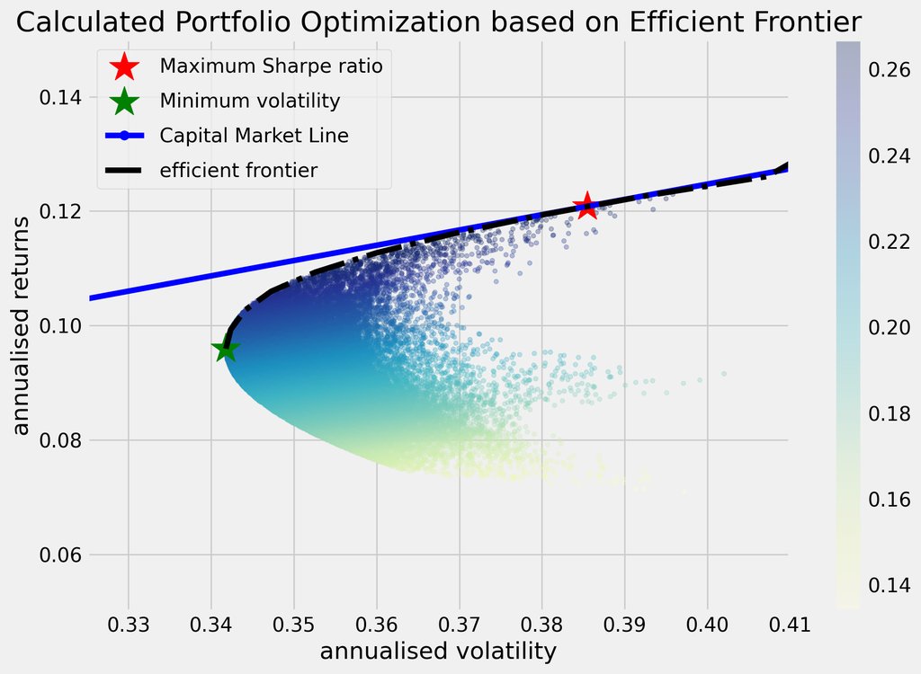

```python
display_calculated_ef_with_random(mean_returns, cov_matrix, num_portfolios, risk_free_rate)
```

We have almost the same result as what we have simulated by picking from the randomly generated portfolios. There are some differences in the decimal places but more or less same.

Instead of plotting every randomly generated portfolio, we can plot each individual stocks on the plot with the corresponding values of each stock's annual return and annual risk. This way we can see and compare how diversification is lowering the risk by optimising the allocation.

```python
def display_ef_with_selected(mean_returns, cov_matrix, risk_free_rate):
    max_sharpe = max_sharpe_ratio(mean_returns, cov_matrix, risk_free_rate)
    sdp, rp = portfolio_annualised_performance(max_sharpe['x'], mean_returns, cov_matrix)
    max_sharpe_allocation = pd.DataFrame(max_sharpe.x,index=table.columns,columns=['allocation'])
    max_sharpe_allocation.allocation = [round(i*100,2)for i in max_sharpe_allocation.allocation]
    max_sharpe_allocation = max_sharpe_allocation.T
    max_sharpe_allocation

    min_vol = min_variance(mean_returns, cov_matrix)
    sdp_min, rp_min = portfolio_annualised_performance(min_vol['x'], mean_returns, cov_matrix)
    min_vol_allocation = pd.DataFrame(min_vol.x,index=table.columns,columns=['allocation'])
    min_vol_allocation.allocation = [round(i*100,2)for i in min_vol_allocation.allocation]
    min_vol_allocation = min_vol_allocation.T

    an_vol = np.std(returns) * np.sqrt(trading_days_per_year)
    an_rt = mean_returns * trading_days_per_year

    print ("-"*80)
    print ("Maximum Sharpe Ratio Portfolio Allocation\n")
    print ("Annualised Return:", round(rp,2))
    print ("Annualised Volatility:", round(sdp,2))
    print ("\n")
    print (max_sharpe_allocation)
    print ("-"*80)
    print ("Minimum Volatility Portfolio Allocation\n")
    print ("Annualised Return:", round(rp_min,2))
    print ("Annualised Volatility:", round(sdp_min,2))
    print ("\n")
    print (min_vol_allocation)
    print ("-"*80)
    print ("Individual Stock Returns and Volatility\n")
    for i, txt in enumerate(table.columns):
        print (txt,":","annuaised return",round(an_rt[i],2),", annualised volatility:",round(an_vol[i],2))
    print ("-"*80)

    fig, ax = plt.subplots(figsize=(10, 7))
    ax.scatter(an_vol,an_rt,marker='o',s=200)

    for i, txt in enumerate(table.columns):
        ax.annotate(txt, (an_vol[i],an_rt[i]), xytext=(10,0), textcoords='offset points')
    ax.scatter(sdp,rp,marker='*',color='r',s=500, label='Maximum Sharpe ratio')
    ax.scatter(sdp_min,rp_min,marker='*',color='g',s=500, label='Minimum volatility')

    target = np.linspace(rp_min, 0.26, 50)
    efficient_portfolios = efficient_frontier(mean_returns, cov_matrix, target)
    plt.plot([p['fun'] for p in efficient_portfolios], target, linestyle='-.', color='black', label='efficient frontier')
    plt.xlim([.325,.41])
    plt.ylim([0.05, 0.15])
    ax.set_title('Portfolio Optimization with Individual Stocks')
    ax.set_xlabel('annualised volatility')
    ax.set_ylabel('annualised returns')
    ax.legend(labelspacing=0.8)
```

```
--------------------------------------------------------------------------------
Maximum Sharpe Ratio Portfolio Allocation

Annualised Return: 0.12
Annualised Volatility: 0.39


            MBB    VIB    CTG   BID
allocation  0.0  84.63  11.03  4.34
--------------------------------------------------------------------------------
Minimum Volatility Portfolio Allocation

Annualised Return: 0.1
Annualised Volatility: 0.34


              MBB    VIB    CTG    BID
allocation  11.66  33.53  14.85  39.97
--------------------------------------------------------------------------------
Individual Stock Returns and Volatility

MBB : annuaised return 0.07 , annualised volatility: 0.41
VIB : annuaised return 0.13 , annualised volatility: 0.41
CTG : annuaised return 0.09 , annualised volatility: 0.41
BID : annuaised return 0.08 , annualised volatility: 0.38
--------------------------------------------------------------------------------
```

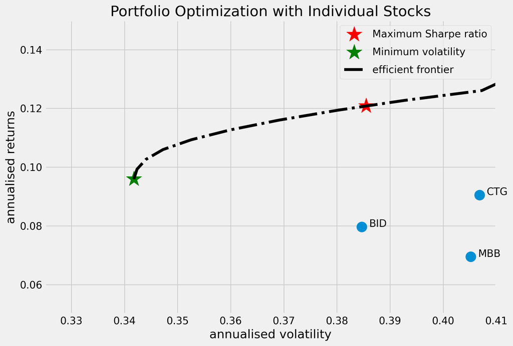

```python
display_ef_with_selected(mean_returns, cov_matrix, risk_free_rate)
```

References:

- https://www.investopedia.com/terms/e/efficientfrontier.asp -https://www.investopedia.com/terms/c/cml.asp#:~:text=What%20Is%20the%20Capital%20Market,market%20portfolio%20of%20risky%20assets.
- https://www.machinelearningplus.com/machine-learning/portfolio-optimization-python-example/?fbclid=IwAR0VHpmVY11zELyzvChjWM7ZoOtDmCBn9JX9BfuOfy056iYYfVgvcOGdxD0
- https://colab.research.google.com/drive/1ulDSw7DEJH1SYRVwvtJXYU0naFgaaBiR#scrollTo=2ttvT3Ry3tJU